# EasyVisa_Full_Code (2)

## Data Pre-processing

### Outlier Check

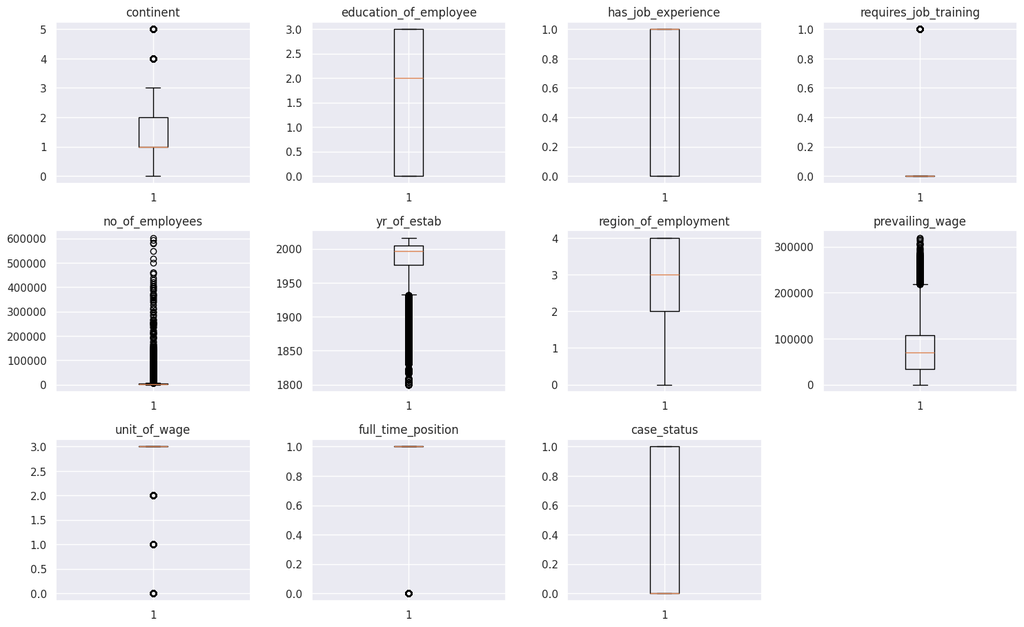

```python
data_encoded = data2.copy()

for col in data_encoded.select_dtypes(include='category').columns:
    data_encoded[col] = data_encoded[col].cat.codes

numeric_columns = data_encoded.select_dtypes(include=np.number).columns.tolist()

plt.figure(figsize=(15, 12))

for i, variable in enumerate(numeric_columns):
    plt.subplot(4, 4, i + 1)
    plt.boxplot(data_encoded[variable], whis=1.5)
    plt.tight_layout()
    plt.title(variable)

plt.show()
```

### Data Preparation for modeling

```python
X = data2.drop(["case_status"], axis=1)
y = data2["case_status"]

# dropping the target variable
```

```python
X_temp, X_test, y_temp, y_test = train_test_split(
    X, y, test_size=0.3, random_state=1, stratify=y
)

# then we split the temporary set into train and validation

X_train, X_val, y_train, y_val = train_test_split(
    X_temp, y_temp, test_size=0.25, random_state=1, stratify=y_temp
)
print(X_train.shape, X_val.shape, X_test.shape)

# X_train, X_test, y_train, y_test = train_test_split(X, y, test_size=0.30, random_state=1, shuffle=True)
```

```
(13377, 10) (4459, 10) (7644, 10)
```

```python
X_train.shape, X_val.shape
```

```
((13377, 10), (4459, 10))
```

```python
import pandas as pd
from sklearn.impute import SimpleImputer

# Get list of categorical and numerical columns
cat_cols = list(X_train.select_dtypes(include='category').columns)
num_cols = list(X_train.select_dtypes(include=['int', 'float']).columns)

# Impute categorical columns
cat_imputer = SimpleImputer(strategy='most_frequent')
X_train[cat_cols] = cat_imputer.fit_transform(X_train[cat_cols])
X_val[cat_cols] = cat_imputer.transform(X_val[cat_cols])
X_test[cat_cols] = cat_imputer.transform(X_test[cat_cols])

# Impute numerical columns
num_imputer = SimpleImputer(strategy='mean')
X_train[num_cols] = num_imputer.fit_transform(X_train[num_cols])
X_val[num_cols] = num_imputer.transform(X_val[num_cols])
X_test[num_cols] = num_imputer.transform(X_test[num_cols])
data2.info()
```

```
<class 'pandas.core.frame.DataFrame'>
RangeIndex: 25480 entries, 0 to 25479
Data columns (total 11 columns):
 #   Column                 Non-Null Count  Dtype
---  ------                 --------------  -----
 0   continent              25480 non-null  category
 1   education_of_employee  25480 non-null  category
 2   has_job_experience     25480 non-null  category
 3   requires_job_training  25480 non-null  category
 4   no_of_employees        25480 non-null  int64
 5   yr_of_estab            25480 non-null  int64
 6   region_of_employment   25480 non-null  category
 7   prevailing_wage        25480 non-null  float64
 8   unit_of_wage           25480 non-null  category
 9   full_time_position     25480 non-null  category
 10  case_status            25480 non-null  category
dtypes: category(8), float64(1), int64(2)
memory usage: 797.7 KB
```

```python
# Checking that no column has missing values in train, validation or test sets
print(X_train.isna().sum())
print("-" * 30)
print(X_val.isna().sum())
print("-" * 30)
print(X_test.isna().sum())
```

```
continent                0
education_of_employee    0
has_job_experience       0
requires_job_training    0
no_of_employees          0
yr_of_estab              0
region_of_employment     0
prevailing_wage          0
unit_of_wage             0
full_time_position       0
dtype: int64
------------------------------
continent                0
education_of_employee    0
has_job_experience       0
requires_job_training    0
no_of_employees          0
yr_of_estab              0
region_of_employment     0
prevailing_wage          0
unit_of_wage             0
full_time_position       0
dtype: int64
------------------------------
continent                0
education_of_employee    0
has_job_experience       0
requires_job_training    0
no_of_employees          0
yr_of_estab              0
region_of_employment     0
prevailing_wage          0
unit_of_wage             0
full_time_position       0
dtype: int64
```

```python
data2.isnull().sum()
```

|  | 0 |
| --- | --- |
| continent | 0 |
| education_of_employee | 0 |
| has_job_experience | 0 |
| requires_job_training | 0 |
| no_of_employees | 0 |
| yr_of_estab | 0 |
| region_of_employment | 0 |
| prevailing_wage | 0 |
| unit_of_wage | 0 |
| full_time_position | 0 |
| case_status | 0 |

**dtype:** int64

## Model Building

### Model Evaluation Criterion

```python
# defining a function to compute different metrics to check performance of a classification model built using sklearn


def model_performance_classification_sklearn(model, predictors, target):
    """
    Function to compute different metrics to check classification model performance

    model: classifier
    predictors: independent variables
    target: dependent variable
    """

    # predicting using the independent variables
    pred = model.predict(predictors)

    acc = accuracy_score(target, pred)  # to compute Accuracy
    recall = recall_score(target, pred)  # to compute Recall
    precision = precision_score(target, pred)  # to compute Precision
    f1 = f1_score(target, pred)  # to compute F1-score

    # creating a dataframe of metrics
    df_perf = pd.DataFrame(
        {"Accuracy": acc, "Recall": recall, "Precision": precision, "F1": f1,},
        index=[0],
    )

    return df_perf
```

```python
def confusion_matrix_sklearn(model, predictors, target):
    """
    To plot the confusion_matrix with percentages

    model: classifier
    predictors: independent variables
    target: dependent variable
    """
    y_pred = model.predict(predictors)
    cm = confusion_matrix(target, y_pred)
    labels = np.asarray(
        [
            ["{0:0.0f}".format(item) + "\n{0:.2%}".format(item / cm.flatten().sum())]
            for item in cm.flatten()
        ]
    ).reshape(2, 2)

    plt.figure(figsize=(6, 4))
    sns.heatmap(cm, annot=labels, fmt="")
    plt.ylabel("True label")
    plt.xlabel("Predicted label")
```

**We are now done with pre-processing and evaluation criterion, so let's start building the model.**

### Model building with original data

```python
models = []

models.append(("Bagging", BaggingClassifier(estimator=DecisionTreeClassifier(random_state=1, class_weight='balanced'), random_state=1)))
models.append(("Random forest", RandomForestClassifier(random_state=1, class_weight='balanced')))
models.append(("GBM", GradientBoostingClassifier(random_state=1)))
models.append(("Adaboost", AdaBoostClassifier(random_state=1)))
models.append(("dtree", DecisionTreeClassifier(random_state=1, class_weight='balanced')))

print("\nTraining Performance:\n")
for name, model in models:
    model.fit(X_train, y_train)
    scores = recall_score(y_train, model.predict(X_train))
    print("{}: {}".format(name, scores))

print("\nValidation Performance:\n")
for name, model in models:
    model.fit(X_train, y_train)
    scores_val = recall_score(y_val, model.predict(X_val))
    print("{}: {}".format(name, scores_val))

# adding the 5 models and running the training and validation tests on it, this is right out of the gate before anything is done to it
```

```
Training Performance:

Bagging: 0.9863458310016788
Random forest: 1.0
GBM: 0.8846110800223839
Adaboost: 0.8878567431449357
dtree: 1.0

Validation Performance:

Bagging: 0.7991940899932841
Random forest: 0.8707186030893217
GBM: 0.8935527199462726
Adaboost: 0.8989254533243788
dtree: 0.7635997313633311
```

```python
print("\nTraining and Validation Performance Difference:\n")

for name, model in models:
    model.fit(X_train, y_train)
    scores_train = recall_score(y_train, model.predict(X_train))
    scores_val = recall_score(y_val, model.predict(X_val))
    difference1 = scores_train - scores_val
    print("{}: Training Score: {:.4f}, Validation Score: {:.4f}, Difference: {:.4f}".format(name, scores_train, scores_val, difference1))

# getting the diff between the 2 tests to see how they stack up against each other and also to see room for improvement.
```

```
Training and Validation Performance Difference:

Bagging: Training Score: 0.9863, Validation Score: 0.7992, Difference: 0.1872
Random forest: Training Score: 1.0000, Validation Score: 0.8707, Difference: 0.1293
GBM: Training Score: 0.8846, Validation Score: 0.8936, Difference: -0.0089
Adaboost: Training Score: 0.8879, Validation Score: 0.8989, Difference: -0.0111
dtree: Training Score: 1.0000, Validation Score: 0.7636, Difference: 0.2364
```

### Model Building with oversampled data

```python
print("Before Oversampling, counts of label 'Yes': {}".format(sum(y_train == 1)))
print("Before Oversampling, counts of label 'No': {} \n".format(sum(y_train == 0)))

sm = SMOTE(
    sampling_strategy=1, k_neighbors=5, random_state=1
)  # Synthetic Minority Over Sampling Technique
X_train_over, y_train_over = sm.fit_resample(X_train, y_train)


print("After Oversampling, counts of label 'Yes': {}".format(sum(y_train_over == 1)))
print("After Oversampling, counts of label 'No': {} \n".format(sum(y_train_over == 0)))


print("After Oversampling, the shape of train_X: {}".format(X_train_over.shape))
print("After Oversampling, the shape of train_y: {} \n".format(y_train_over.shape))

# running SMOTE on the dataset for over/under sampling to see if the ds changes at all, only the over changes for NO after running it which means some folks were on the border
```

```
Before Oversampling, counts of label 'Yes': 8935
Before Oversampling, counts of label 'No': 4442

After Oversampling, counts of label 'Yes': 8935
After Oversampling, counts of label 'No': 8935

After Oversampling, the shape of train_X: (17870, 10)
After Oversampling, the shape of train_y: (17870,)
```

```python
X_train_over.isnull().sum()
```

|  | 0 |
| --- | --- |
| continent | 0 |
| education_of_employee | 0 |
| has_job_experience | 0 |
| requires_job_training | 0 |
| no_of_employees | 0 |
| yr_of_estab | 0 |
| region_of_employment | 0 |
| prevailing_wage | 0 |
| unit_of_wage | 0 |
| full_time_position | 0 |

**dtype:** int64

```python
models = []  # Empty list to store all the models

# Appending models into the list
models.append(("Bagging", BaggingClassifier(estimator=DecisionTreeClassifier(random_state=1, class_weight='balanced'), random_state=1)))
models.append(("Random forest", RandomForestClassifier(random_state=1, class_weight='balanced')))
models.append(("GBM", GradientBoostingClassifier(random_state=1)))
models.append(("Adaboost", AdaBoostClassifier(random_state=1)))
models.append(("dtree", DecisionTreeClassifier(random_state=1, class_weight='balanced')))

print("\n" "Training Performance:" "\n")
for name, model in models:
    model.fit(X_train_over, y_train_over)
    scores = recall_score(y_train_over, model.predict(X_train_over))
    print("{}: {}".format(name, scores))

print("\n" "Validation Performance:" "\n")

for name, model in models:
    model.fit(X_train_over, y_train_over)
    scores = recall_score(y_val, model.predict(X_val))
    print("{}: {}".format(name, scores))

# running the validation tests on the OG data to see how the data reacts
# GBM and Ada models did well and increased their numbers which means they generalized well
```

```
Training Performance:

Bagging: 0.9748181309457191
Random forest: 1.0
GBM: 0.7898153329602686
Adaboost: 0.7838836038052602
dtree: 1.0

Validation Performance:

Bagging: 0.7374076561450638
Random forest: 0.7971793149764943
GBM: 0.7978509066487576
Adaboost: 0.7931497649429147
dtree: 0.708865010073875
```

```python
print("\nTraining and Validation Performance Difference:\n")

for name, model in models:
    model.fit(X_train_over, y_train_over)
    scores_train = recall_score(y_train_over, model.predict(X_train_over))
    scores_val = recall_score(y_val, model.predict(X_val))
    difference2 = scores_train - scores_val
    print("{}: Training Score: {:.4f}, Validation Score: {:.4f}, Difference: {:.4f}".format(name, scores_train, scores_val, difference2))
```

```
Training and Validation Performance Difference:

Bagging: Training Score: 0.9748, Validation Score: 0.7374, Difference: 0.2374
Random forest: Training Score: 1.0000, Validation Score: 0.7972, Difference: 0.2028
GBM: Training Score: 0.7898, Validation Score: 0.7979, Difference: -0.0080
Adaboost: Training Score: 0.7839, Validation Score: 0.7931, Difference: -0.0093
dtree: Training Score: 1.0000, Validation Score: 0.7089, Difference: 0.2911
```

### Model Building with undersampled data

```python
rus = RandomUnderSampler(random_state=1)
X_train_un, y_train_un = rus.fit_resample(X_train, y_train)
```

```python
print("Before Under Sampling, counts of label 'Yes': {}".format(sum(y_train == 1)))
print("Before Under Sampling, counts of label 'No': {} \n".format(sum(y_train == 0)))

print("After Under Sampling, counts of label 'Yes': {}".format(sum(y_train_un == 1)))
print("After Under Sampling, counts of label 'No': {} \n".format(sum(y_train_un == 0)))

print("After Under Sampling, the shape of train_X: {}".format(X_train_un.shape))
print("After Under Sampling, the shape of train_y: {} \n".format(y_train_un.shape))
```

```
Before Under Sampling, counts of label 'Yes': 8935
Before Under Sampling, counts of label 'No': 4442

After Under Sampling, counts of label 'Yes': 4442
After Under Sampling, counts of label 'No': 4442

After Under Sampling, the shape of train_X: (8884, 10)
After Under Sampling, the shape of train_y: (8884,)
```

```python
models = []  # Empty list to store all the models

# Appending models into the list
models.append(("Bagging", BaggingClassifier(estimator=DecisionTreeClassifier(random_state=1, class_weight='balanced'), random_state=1)))
models.append(("Random forest", RandomForestClassifier(random_state=1, class_weight='balanced')))
models.append(("GBM", GradientBoostingClassifier(random_state=1)))
models.append(("Adaboost", AdaBoostClassifier(random_state=1)))
models.append(("dtree", DecisionTreeClassifier(random_state=1, class_weight='balanced')))


print("\n" "Training Performance:" "\n")
for name, model in models:
    model.fit(X_train_un, y_train_un)
    scores = recall_score(y_train_un, model.predict(X_train_un))
    print("{}: {}".format(name, scores))

print("\n" "Validation Performance:" "\n")

for name, model in models:
    model.fit(X_train_un, y_train_un)
    scores = recall_score(y_val, model.predict(X_val))
    print("{}: {}".format(name, scores))

# The high training performance scores could indicate overfitting, where the model is too closely aligned with the training data and might not generalize well
# Models like GBM and Random Forest show relatively good validation performance, which suggests they generalize better than others
```

```
Training Performance:

Bagging: 0.9669067987393066
Random forest: 1.0
GBM: 0.7478613237280505
Adaboost: 0.7014858171994597
dtree: 1.0

Validation Performance:

Bagging: 0.6229012760241773
Random forest: 0.7081934184016119
GBM: 0.7437877770315648
Adaboost: 0.6984553391537945
dtree: 0.6437206178643384
```

```python
print("\nTraining and Validation Performance Difference:\n")

for name, model in models:
    model.fit(X_train_un, y_train_un)
    scores_train = recall_score(y_train_un, model.predict(X_train_un))
    scores_val = recall_score(y_val, model.predict(X_val))
    difference3 = scores_train - scores_val
    print("{}: Training Score: {:.4f}, Validation Score: {:.4f}, Difference: {:.4f}".format(name, scores_train, scores_val, difference3))
```

```
Training and Validation Performance Difference:

Bagging: Training Score: 0.9669, Validation Score: 0.6229, Difference: 0.3440
Random forest: Training Score: 1.0000, Validation Score: 0.7082, Difference: 0.2918
GBM: Training Score: 0.7479, Validation Score: 0.7438, Difference: 0.0041
Adaboost: Training Score: 0.7015, Validation Score: 0.6985, Difference: 0.0030
dtree: Training Score: 1.0000, Validation Score: 0.6437, Difference: 0.3563
```

Chose the random forest, GBM and adaboost models since they were the best performing models across the board for training and validation sets and had promising results

## Random Forest Model Building

```python
rf_wt = RandomForestClassifier(class_weight='balanced', random_state=1)
rf_wt.fit(X_train,y_train)
```

```
RandomForestClassifier(class_weight='balanced', random_state=1)
```

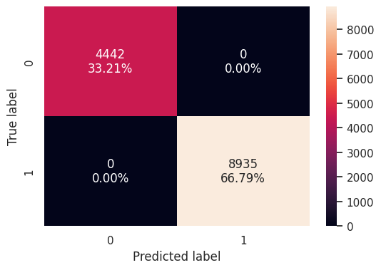

```python
confusion_matrix_sklearn(rf_wt,X_train,y_train)
```

```python
rf_wt_model_train_perf=model_performance_classification_sklearn(rf_wt, X_train,y_train)
print("Training performance \n",rf_wt_model_train_perf)
```

```
Training performance
    Accuracy  Recall  Precision    F1
0     1.000   1.000      1.000 1.000
```

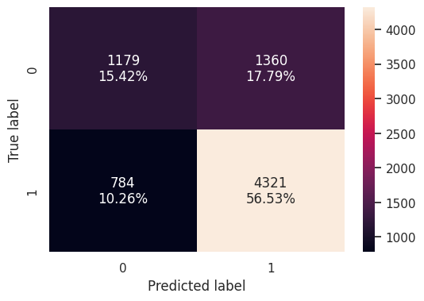

```python
confusion_matrix_sklearn(rf_wt, X_test,y_test)
```

```python
rf_wt_model_test_perf=model_performance_classification_sklearn(rf_wt, X_test,y_test)
print("Testing performance \n",rf_wt_model_test_perf)

# main variable were looking at is recall which means they model is adjusting well with the dataset
```

```
Testing performance
    Accuracy  Recall  Precision    F1
0     0.720   0.846      0.761 0.801
```

## Gradient Boosting Model Building

```python
gb_estimator=GradientBoostingClassifier(random_state=1)
gb_estimator.fit(X_train,y_train)
```

```
GradientBoostingClassifier(random_state=1)
```

```python
gb_estimator_model_train_perf = model_performance_classification_sklearn(gb_estimator, X_train,y_train)
print("Training performance \n",gb_estimator_model_train_perf)
```

```
Training performance
    Accuracy  Recall  Precision    F1
0     0.757   0.885      0.780 0.829
```

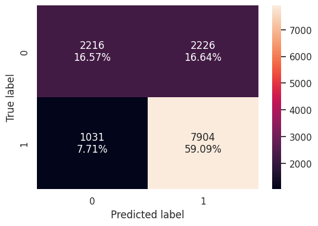

```python
confusion_matrix_sklearn(gb_estimator,X_train,y_train)
```

```python
gb_estimator_model_test_perf = model_performance_classification_sklearn(gb_estimator, X_test, y_test)
print("Testing performance \n",gb_estimator_model_test_perf)
```

```
Testing performance
    Accuracy  Recall  Precision    F1
0     0.743   0.878      0.769 0.820
```

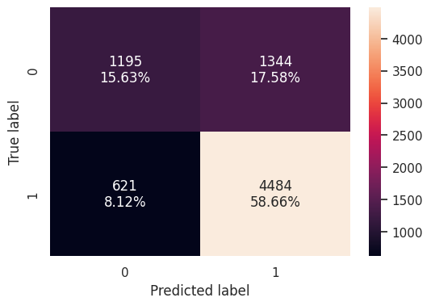

```python
confusion_matrix_sklearn(gb_estimator, X_test,y_test)

# The model is performing reasonably well on both the training and test sets
# with a slight drop in accuracy and precision from training to testing, which is expected due to the model's generalization to unseen data

# The F1 score being similar between the train and test sets suggests that the model is generalizing well
# striking a good balance between false positives and false negatives.
```

## AdaBoost Model Building

```python
ab_classifier = AdaBoostClassifier(random_state=1)
ab_classifier.fit(X_train, y_train)
```

```
AdaBoostClassifier(random_state=1)
```

```python
ab_classifier_model_train_perf = model_performance_classification_sklearn(ab_classifier, X_train, y_train)
print("Training performance \n", ab_classifier_model_train_perf)
```

```
Training performance
    Accuracy  Recall  Precision    F1
0     0.739   0.888      0.761 0.820
```

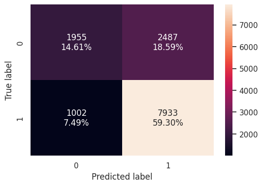

```python
confusion_matrix_sklearn(ab_classifier,X_train,y_train)
```

```python
ab_classifier_model_test_perf = model_performance_classification_sklearn(ab_classifier, X_test, y_test)
print("Testing performance \n", ab_classifier_model_test_perf)
```

```
Testing performance
    Accuracy  Recall  Precision    F1
0     0.733   0.884      0.757 0.815
```

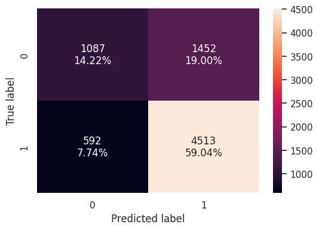

```python
confusion_matrix_sklearn(ab_classifier, X_test,y_test)

# The AdaBoost model is performing well on both the training and testing sets, with a minimal drop in performance between the two.
# The similarity between training and test performance (especially recall) indicates that the model generalizes well to unseen data
# The slight drop in precision from training to testing is expected, but overall, it remains effective
```

## Tuning the GBM Model with undersampled data

```python
%%time

#Creating pipeline
Model = GradientBoostingClassifier(random_state=1)

#Parameter grid to pass in RandomSearchCV
param_grid = {
    "init": [DecisionTreeClassifier(max_depth=1, random_state=1)],
    "n_estimators": np.arange(150, 301, 50),
    "learning_rate": [0.01, 0.05, 0.1],
    "subsample": [0.7, 0.8, 0.9],
    "max_features": [0.5, 0.7],
}
scorer = metrics.make_scorer(metrics.recall_score)

# Calling RandomizedSearchCV
randomized_cv = RandomizedSearchCV(
    estimator=Model,
    param_distributions=param_grid,
    n_iter=50,
    scoring=scorer,
    cv=5,
    random_state=1,
    n_jobs=-1
)

# Fitting RandomizedSearchCV
randomized_cv.fit(X_train_un, y_train_un)

print("Best parameters are {} with CV score={}".format(randomized_cv.best_params_, randomized_cv.best_score_))
```

```
Best parameters are {'subsample': 0.9, 'n_estimators': np.int64(200), 'max_features': 0.7, 'learning_rate': 0.01, 'init': DecisionTreeClassifier(max_depth=1, random_state=1)} with CV score=0.7615944121849634
CPU times: user 4.96 s, sys: 594 ms, total: 5.55 s
Wall time: 5min 36s
```

```python
tuned_gbm1 = GradientBoostingClassifier(
    random_state=1,
    subsample=0.9,
    n_estimators=150,
    max_features=0.5,
    learning_rate=0.01,
    init=DecisionTreeClassifier(random_state=1),
)
tuned_gbm1.fit(X_train_un, y_train_un)
```

```
GradientBoostingClassifier(init=DecisionTreeClassifier(random_state=1),
                           learning_rate=0.01, max_features=0.5,
                           n_estimators=150, random_state=1, subsample=0.9)
```

```python
# Checking model's performance on training set
gbm1_train = model_performance_classification_sklearn(
    tuned_gbm1, X_train_un, y_train_un
)
gbm1_train
```

|  | Accuracy | Recall | Precision | F1 |
| --- | --- | --- | --- | --- |
| 0 | 1.000 | 1.000 | 1.000 | 1.000 |

```python
# Checking model's performance on validation set
gbm1_val = model_performance_classification_sklearn(tuned_gbm1, X_val, y_val)
gbm1_val
```

|  | Accuracy | Recall | Precision | F1 |
| --- | --- | --- | --- | --- |
| 0 | 0.637 | 0.644 | 0.775 | 0.703 |

- The model performed perfectly on the training set but dropped significantly on the validation set, indicating overfitting
- Lower recall and F1 on the validation set suggest the model misses many positive cases.

## Tuning the GBM Model with Oversampled data

```python
%%time

# Defining the model
Model = GradientBoostingClassifier(random_state=1)

# Parameter grid
param_grid = {
    "init": [DecisionTreeClassifier(max_depth=1, random_state=1)],   # simpler init model
    "n_estimators": np.arange(150, 301, 50),                         # slightly more trees
    "learning_rate": [0.01, 0.05, 0.1],                              # smaller learning rates
    "subsample": [0.7, 0.8, 0.9],                                    # avoid overfitting
    "max_features": [0.5, 0.7],                                      # use fewer features randomly
}

# Scoring function (focus on recall)
scorer = metrics.make_scorer(metrics.recall_score)

# Calling RandomizedSearchCV
randomized_cv = RandomizedSearchCV(
    estimator=Model,
    param_distributions=param_grid,
    n_iter=50,
    scoring=scorer,
    cv=5,
    random_state=1,
    n_jobs=-1
)

# Fitting RandomizedSearchCV on oversampled data
randomized_cv.fit(X_train_over, y_train_over)

# Printing best parameters
print("Best parameters are {} with CV score={}".format(randomized_cv.best_params_, randomized_cv.best_score_))
```

```
Best parameters are {'subsample': 0.7, 'n_estimators': np.int64(300), 'max_features': 0.7, 'learning_rate': 0.1, 'init': DecisionTreeClassifier(max_depth=1, random_state=1)} with CV score=0.7889199776161163
CPU times: user 9.87 s, sys: 953 ms, total: 10.8 s
Wall time: 10min 53s
```

```python
tuned_gbm2 = GradientBoostingClassifier(
    random_state=1,
    subsample=0.7,
    n_estimators=150,
    max_features=1,
    learning_rate=1,
    init=AdaBoostClassifier(random_state=1),
)
tuned_gbm2.fit(X_train_over, y_train_over)
```

```
GradientBoostingClassifier(init=AdaBoostClassifier(random_state=1),
                           learning_rate=1, max_features=1, n_estimators=150,
                           random_state=1, subsample=0.7)
```

```python
# Checking model's performance on training set
gbm2_train = model_performance_classification_sklearn(tuned_gbm1, X_train_over, y_train_over)
gbm2_train
```

|  | Accuracy | Recall | Precision | F1 |
| --- | --- | --- | --- | --- |
| 0 | 0.853 | 0.814 | 0.883 | 0.847 |

```python
# Checking model's performance on validation set
gbm2_val = model_performance_classification_sklearn(tuned_gbm1, X_val, y_val)
gbm2_val
```

|  | Accuracy | Recall | Precision | F1 |
| --- | --- | --- | --- | --- |
| 0 | 0.637 | 0.644 | 0.775 | 0.703 |

- The model shows good performance with high accuracy, recall, and precision, indicating a strong fit on the oversampled training data
- The validation performance drops, with a significant reduction in recall and F1 score, suggesting that the model may have overfitted to the oversampled data and struggles to generalize.

## Tuning RandomForestClassifier model with undersampled data

```python
%%time

# Defining the model
Model = RandomForestClassifier(random_state=1)

# Parameter grid
param_grid = {
    "n_estimators": np.arange(150, 301, 50),         # Number of trees
    "max_depth": [5, 10, 15, None],                 # Depth of each tree
    "min_samples_split": [2, 5, 10],                # Min samples to split a node
    "min_samples_leaf": [1, 2, 4],                  # Min samples at a leaf node
    "max_features": [0.5, 0.7, 1],                  # Number of features to consider at split
    "class_weight": [None, 'balanced']              # Try class balancing
}

# Scoring function (focus on recall)
scorer = metrics.make_scorer(metrics.recall_score)

# Calling RandomizedSearchCV
randomized_cv = RandomizedSearchCV(
    estimator=Model,
    param_distributions=param_grid,
    n_iter=50,
    scoring=scorer,
    cv=5,
    random_state=1,
    n_jobs=-1
)

# Fitting RandomizedSearchCV on undersampled data
randomized_cv.fit(X_train_un, y_train_un)

# Printing best parameters
print("Best parameters are {} with CV score={}".format(randomized_cv.best_params_, randomized_cv.best_score_))
```

```
Best parameters are {'n_estimators': np.int64(250), 'min_samples_split': 2, 'min_samples_leaf': 4, 'max_features': 0.7, 'max_depth': 10, 'class_weight': 'balanced'} with CV score=0.7485402162567516
CPU times: user 8.72 s, sys: 690 ms, total: 9.41 s
Wall time: 9min 4s
```

```python
# Train the final tuned Random Forest model
tuned_rf1 = RandomForestClassifier(
    random_state=1,
    n_estimators=150,
    max_depth=10,
    min_samples_split=2,
    min_samples_leaf=1,
    max_features=0.7,
    class_weight='balanced'
)

tuned_rf1.fit(X_train_un, y_train_un)
```

```
RandomForestClassifier(class_weight='balanced', max_depth=10, max_features=0.7,
                       n_estimators=150, random_state=1)
```

```python
# Checking model's performance on training set
rf1_train = model_performance_classification_sklearn(
    tuned_rf1, X_train_un, y_train_un
)
rf1_train
```

|  | Accuracy | Recall | Precision | F1 |
| --- | --- | --- | --- | --- |
| 0 | 0.800 | 0.845 | 0.776 | 0.809 |

```python
# Checking model's performance on validation set
rf1_val = model_performance_classification_sklearn(tuned_rf1, X_val, y_val)
rf1_val
```

|  | Accuracy | Recall | Precision | F1 |
| --- | --- | --- | --- | --- |
| 0 | 0.724 | 0.758 | 0.815 | 0.786 |

- The model demonstrates balanced performance with decent accuracy, recall, precision, and F1 score, indicating good learning on the training data
- The performance remains consistent with the training set, suggesting that the model is generalizing well and not overfitting.

## Tuning RandomForestClassifier model with oversampled data

```python
%%time

# Defining the model
Model = RandomForestClassifier(random_state=1)

# Parameter grid
param_grid = {
    "n_estimators": np.arange(150, 301, 50),         # Number of trees
    "max_depth": [5, 10, 15, None],                  # Depth of each tree
    "min_samples_split": [2, 5, 10],                 # Minimum samples to split a node
    "min_samples_leaf": [1, 2, 4],                   # Minimum samples at a leaf node
    "max_features": [0.5, 0.7, 1],                   # Features considered at each split
    "class_weight": [None, "balanced"]               # Try class balancing
}

# Scoring function (focus on recall)
scorer = metrics.make_scorer(metrics.recall_score)

# Calling RandomizedSearchCV
randomized_cv = RandomizedSearchCV(
    estimator=Model,
    param_distributions=param_grid,
    n_iter=50,
    scoring=scorer,
    cv=5,
    random_state=1,
    n_jobs=-1
)

# Fitting RandomizedSearchCV on oversampled data
randomized_cv.fit(X_train_over, y_train_over)

# Printing best parameters
print("Best parameters are {} with CV score={}".format(randomized_cv.best_params_, randomized_cv.best_score_))
```

```
Best parameters are {'n_estimators': np.int64(250), 'min_samples_split': 10, 'min_samples_leaf': 1, 'max_features': 1, 'max_depth': 15, 'class_weight': None} with CV score=0.7985450475657527
CPU times: user 11.3 s, sys: 1.46 s, total: 12.8 s
Wall time: 17min 36s
```

```python
# Train the final tuned Random Forest model on oversampled data
tuned_rf2 = RandomForestClassifier(
    random_state=1,
    n_estimators=150,
    max_depth=10,
    min_samples_split=2,
    min_samples_leaf=1,
    max_features=0.7,
    class_weight='balanced'
)

tuned_rf2.fit(X_train_over, y_train_over)
```

```
RandomForestClassifier(class_weight='balanced', max_depth=10, max_features=0.7,
                       n_estimators=150, random_state=1)
```

```python
# Checking model's performance on training set
rf2_train = model_performance_classification_sklearn(
    tuned_rf2, X_train_over, y_train_over
)
rf2_train
```

|  | Accuracy | Recall | Precision | F1 |
| --- | --- | --- | --- | --- |
| 0 | 0.823 | 0.841 | 0.812 | 0.826 |

```python
# Checking model's performance on validation set
rf2_val = model_performance_classification_sklearn(tuned_rf2, X_val, y_val)
rf2_val
```

|  | Accuracy | Recall | Precision | F1 |
| --- | --- | --- | --- | --- |
| 0 | 0.739 | 0.811 | 0.801 | 0.806 |

- The model performs well with high accuracy, recall, and F1 score, suggesting it has effectively learned from the oversampled data.
- While the validation performance is slightly lower than training, the recall and F1 score are still strong, showing that the model is maintaining good generalization.

## Tuning AdaBoost model with undersampled data

```python
%%time

# defining model
Model = AdaBoostClassifier(random_state=1)

# Parameter grid to pass in RandomSearchCV
param_grid = {
    "n_estimators": np.arange(10, 40, 10),
    "learning_rate": [0.1, 0.01, 0.2, 0.05, 1],
    "estimator": [
        DecisionTreeClassifier(max_depth=1, random_state=1),
        DecisionTreeClassifier(max_depth=2, random_state=1),
        DecisionTreeClassifier(max_depth=3, random_state=1),
    ],
}

# Type of scoring used to compare parameter combinations
scorer = metrics.make_scorer(metrics.recall_score)

#Calling RandomizedSearchCV
randomized_cv = RandomizedSearchCV(estimator=Model, param_distributions=param_grid, n_jobs = -1, n_iter=50, scoring=scorer, cv=5, random_state=1)

#Fitting parameters in RandomizedSearchCV
randomized_cv.fit(X_train_un, y_train_un)

print("Best parameters are {} with CV score={}:" .format(randomized_cv.best_params_,randomized_cv.best_score_))
```

```
Best parameters are {'n_estimators': np.int64(30), 'learning_rate': 0.05, 'estimator': DecisionTreeClassifier(max_depth=1, random_state=1)} with CV score=0.8036930349922476:
CPU times: user 985 ms, sys: 113 ms, total: 1.1 s
Wall time: 37 s
```

```python
tuned_adb = AdaBoostClassifier(
    random_state=1,
    n_estimators=20,
    learning_rate=0.1,
    estimator=DecisionTreeClassifier(max_depth=2, random_state=1),
)
tuned_adb.fit(X_train_un, y_train_un)
```

```
AdaBoostClassifier(estimator=DecisionTreeClassifier(max_depth=2,
                                                    random_state=1),
                   learning_rate=0.1, n_estimators=20, random_state=1)
```

```python
# Checking model's performance on training set
adb_train = model_performance_classification_sklearn(tuned_adb, X_train_un, y_train_un)
adb_train
```

|  | Accuracy | Recall | Precision | F1 |
| --- | --- | --- | --- | --- |
| 0 | 0.684 | 0.782 | 0.654 | 0.712 |

```python
# Checking model's performance on validation set
adb_val = model_performance_classification_sklearn(tuned_adb, X_val, y_val)
adb_val
```

|  | Accuracy | Recall | Precision | F1 |
| --- | --- | --- | --- | --- |
| 0 | 0.721 | 0.781 | 0.796 | 0.789 |

- The model shows moderate accuracy and recall with a balanced F1 score, indicating it learns the data but might have room for improvement in precision
- The validation performance improves slightly with a solid recall and precision score, suggesting good generalization while maintaining a balanced F1 score.

## Model Performances

```python
# training performance comparison

models_train_comp_df = pd.concat(
    [
        gbm1_train.T,
        gbm2_train.T,
        rf1_train.T,
        rf2_train.T,
        adb_train.T,
    ],
    axis=1,
)
models_train_comp_df.columns = [
    "GBM trained with Undersampled data",
    "GBM trained with Oversampled data",
    "Random Forest trained with Undersampled data",
    "Random Forest trained with Oversampled data",
    "AdaBoost Forest trained with Undersampled data",
    ]
print("Training performance comparison:")
models_train_comp_df
```

```
Training performance comparison:
```

|  | GBM trained with Undersampled data | GBM trained with Oversampled data | Random Forest trained with Undersampled data | Random Forest trained with Oversampled data | AdaBoost Forest trained with Undersampled data |
| --- | --- | --- | --- | --- | --- |
| Accuracy | 1.000 | 0.853 | 0.800 | 0.823 | 0.684 |
| Recall | 1.000 | 0.814 | 0.845 | 0.841 | 0.782 |
| Precision | 1.000 | 0.883 | 0.776 | 0.812 | 0.654 |
| F1 | 1.000 | 0.847 | 0.809 | 0.826 | 0.712 |

-GBM trained with Undersampled data: This model achieved perfect performance across all metrics, but it likely overfits the training data, which might not generalize well.

-GBM trained with Oversampled data: The model showed solid performance with high accuracy and balanced recall, precision, and F1 score, suggesting better generalization on the oversampled dataset.

-Random Forest trained with Undersampled data: The model performed well with high recall, though accuracy and precision were slightly lower, indicating it might be biased toward detecting positive cases.

-Random Forest trained with Oversampled data: With a slight improvement in accuracy and F1 score, this model demonstrated better performance compared to the undersampled version.

-AdaBoost trained with Undersampled data: This model had the lowest performance across all metrics, particularly in recall and precision, indicating that it struggles to handle the undersampled data effectively.

```python
# Validation performance comparison

models_train_comp_df = pd.concat(
    [ gbm1_val.T,
        gbm2_val.T,
        rf1_val.T,
        rf2_val.T,
        adb_val.T,
    ]
    , axis=1,
)
models_train_comp_df.columns = [
    "GBM trained with Undersampled data",
    "GBM trained with Oversampled data",
    "Random Forest trained with Undersampled data",
    "Random Forest trained with Oversampled data",
    "AdaBoost Forest trained with Undersampled data",
]
print("Validation performance comparison:")
models_train_comp_df
```

```
Validation performance comparison:
```

|  | GBM trained with Undersampled data | GBM trained with Oversampled data | Random Forest trained with Undersampled data | Random Forest trained with Oversampled data | AdaBoost Forest trained with Undersampled data |
| --- | --- | --- | --- | --- | --- |
| Accuracy | 0.637 | 0.637 | 0.724 | 0.739 | 0.721 |
| Recall | 0.644 | 0.644 | 0.758 | 0.811 | 0.781 |
| Precision | 0.775 | 0.775 | 0.815 | 0.801 | 0.796 |
| F1 | 0.703 | 0.703 | 0.786 | 0.806 | 0.789 |

-GBM trained with Undersampled data: The validation results show moderate performance, with balanced recall and precision, but the model’s accuracy and F1 score could be improved.

-GBM trained with Oversampled data: Similar to the undersampled version, this model shows balanced recall and precision but could benefit from higher accuracy and F1 score.

-Random Forest trained with Undersampled data: This model performed better on the validation set with a noticeable improvement in recall and precision, leading to a higher F1 score than the GBM models.

-Random Forest trained with Oversampled data: The model showed a slight increase in recall and F1 score, suggesting that oversampling has improved its generalization and classification performance.

-AdaBoost trained with Undersampled data: With strong recall and precision, this model performed well in terms of F1 score, though there is still room for improvement in accuracy.

```python
# Let's check the performance on test set
rf_test = model_performance_classification_sklearn(tuned_rf1, X_test, y_test)
rf_test
```

|  | Accuracy | Recall | Precision | F1 |
| --- | --- | --- | --- | --- |
| 0 | 0.708 | 0.742 | 0.805 | 0.772 |

```python
# Let's check the performance on test set
rf_test2 = model_performance_classification_sklearn(tuned_rf2, X_test, y_test)
rf_test2

#winner for best model with highest recall score, others were close but random forest did good several times and ended up being #1
```

|  | Accuracy | Recall | Precision | F1 |
| --- | --- | --- | --- | --- |
| 0 | 0.716 | 0.791 | 0.786 | 0.788 |

```python
# Let's check the performance on test set
gbm_test = model_performance_classification_sklearn(tuned_gbm1, X_test, y_test)
gbm_test
```

|  | Accuracy | Recall | Precision | F1 |
| --- | --- | --- | --- | --- |
| 0 | 0.620 | 0.629 | 0.760 | 0.688 |

```python
# Let's check the performance on test set
gbm_test2 = model_performance_classification_sklearn(tuned_gbm2, X_test, y_test)
gbm_test2
```

|  | Accuracy | Recall | Precision | F1 |
| --- | --- | --- | --- | --- |
| 0 | 0.702 | 0.774 | 0.779 | 0.776 |

```python
# Let's check the performance on test set
ada_test = model_performance_classification_sklearn(tuned_adb, X_test, y_test)
ada_test
```

|  | Accuracy | Recall | Precision | F1 |
| --- | --- | --- | --- | --- |
| 0 | 0.714 | 0.780 | 0.789 | 0.784 |

## Feature Importance

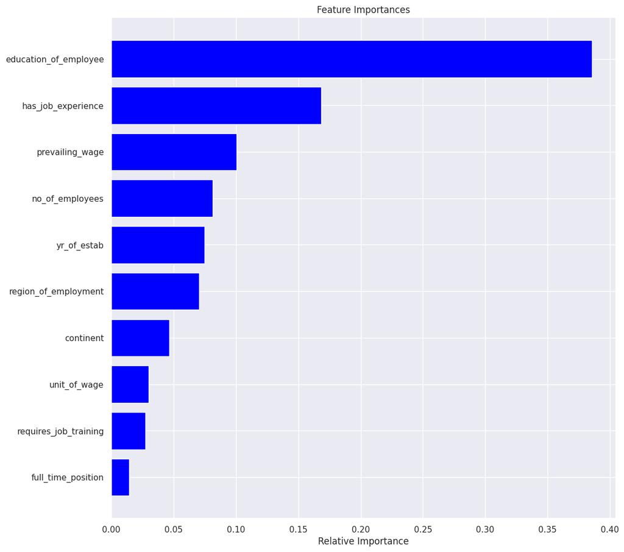

```python
feature_names = X_train.columns
importances = tuned_rf2.feature_importances_
indices = np.argsort(importances)

plt.figure(figsize=(12, 12))
plt.title("Feature Importances")
plt.barh(range(len(indices)), importances[indices], color="blue", align="center")
plt.yticks(range(len(indices)), [feature_names[i] for i in indices])
plt.xlabel("Relative Importance")
plt.show()
```

## Actionable Insights and Recommendations

# Key Insights & Suggestions

-Best Model: The Random Forest model (rf_test2) did the best job overall, with a solid F1 score of 0.788. It balanced precision (0.786) and recall (0.791) well, making it the most reliable for predicting visa approvals.

-Close Second: The AdaBoost model also did well, with an F1 score of 0.784 and slightly better precision (0.789) than the Random Forest. It's a good backup option.

# Suggestions for Improving the Process:

-Two Stage Screening:

-Use the Random Forest model as the main tool to screen applications.

-For tricky cases, double check with the AdaBoost model to avoid wrong denials. This way, you get better accuracy and fairness in visa decisions.

# Focus on High-Risk Applications:

-Applications that are likely to be denied should get a second look by a person.

-Fast track those with a high chance of approval to save time. This helps use resources more efficiently and reduce backlogs.

# Create a Pre-Screening Tool:

-Build an online tool where people can check their approval chances before applying. This cuts down on applications that are unlikely to be approved and eases the workload.

# Applicant Profile Suggestions: Based on the model’s findings, applicants with these characteristics are more likely to get approved:

# Wage Compliance:

-Make sure the wage offered meets or exceeds the industry standard. Low wages are linked to higher denials.

# High-Demand Areas:

-Jobs in regions with labor shortages tend to get approved more. Focus on these areas when applying.

# Education and Experience:

-Applicants whose education and experience match the job better have a higher chance of approval.

# Full-Time Jobs:

-Full-time positions are more likely to get approved compared to part-time or contract jobs.

# How to Roll This Out:

# Start Small:

-Begin by using the Random Forest model on a small batch of applications.

-Compare how well it works against the current manual process.

-If it improves efficiency, expand it.

# Keep Improving the Model:

-Regularly retrain the model with new data.

-Review the model every few months to keep its predictions sharp.

-Try A/B testing different models to see which one works best

Power Ahead